# Final Project: The Olympics

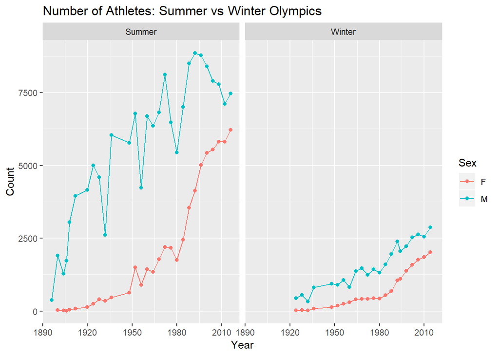

```r
# Side-by-side boxplots or facetted plots for numeric/categorical

  # Number of athletes, grouped by Sex, and facetted by Summer/Winter games. The total number of athletes has been trending upward. There are several dips in the male group, which may be caused by major world wars. There have never been more female athletes, but the gap between men vs women appears to be shrinking.
olympics %>%  group_by(Year, Sex, Season) %>% count() %>% ggplot(aes(x = Year, y = n, colour = Sex)) + geom_point() + geom_line() + ggtitle("Number of Athletes: Summer vs Winter Olympics") + ylab("Count") + facet_wrap(~Season)
```

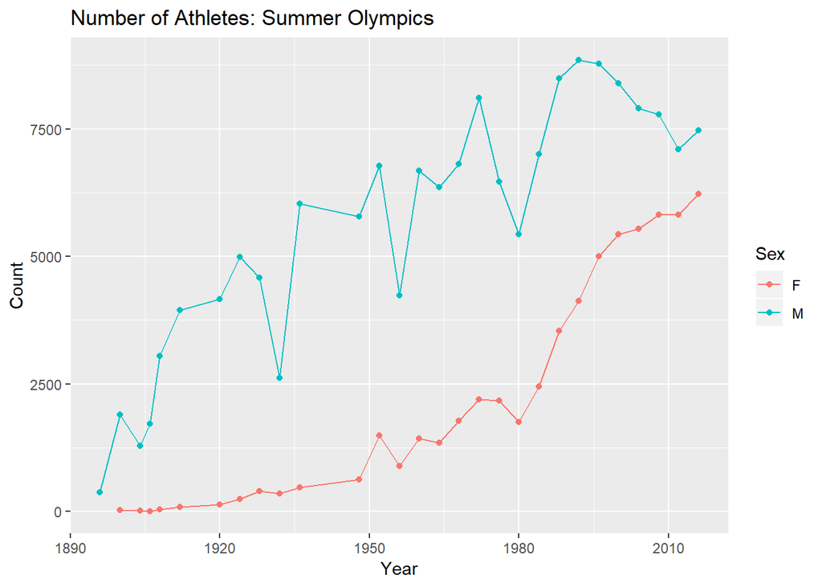

```r
    # Female vs Male athletes by year for summer olympics, a closer look:
olympics %>% filter(Season == "Summer") %>%  group_by(Year, Sex) %>% count() %>% ggplot(aes(x = Year, y = n, colour = Sex)) + geom_point() + geom_line() + ggtitle("Number of Athletes: Summer Olympics") + ylab("Count")
```

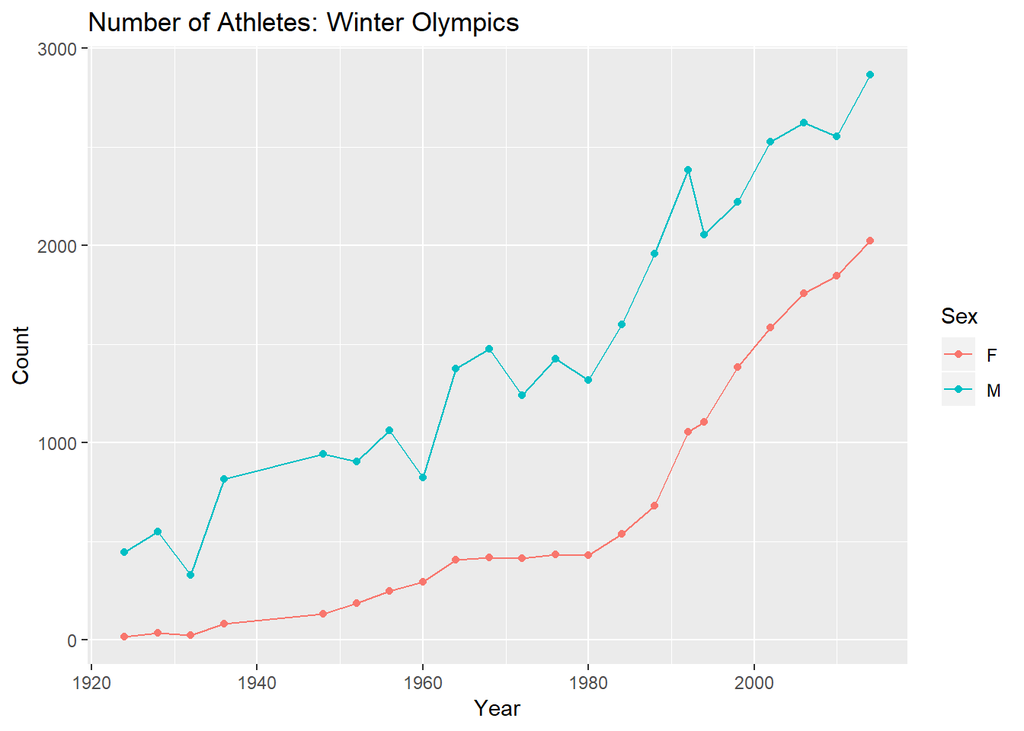

```r
  # Female vs Male athletes by year for winter olympics, a closer look:
olympics %>% filter(Season == "Winter") %>%  group_by(Year, Sex) %>% count() %>% ggplot(aes(x = Year, y = n, colour = Sex)) + geom_point() + geom_line() + ggtitle("Number of Athletes: Winter Olympics") + ylab("Count")
```

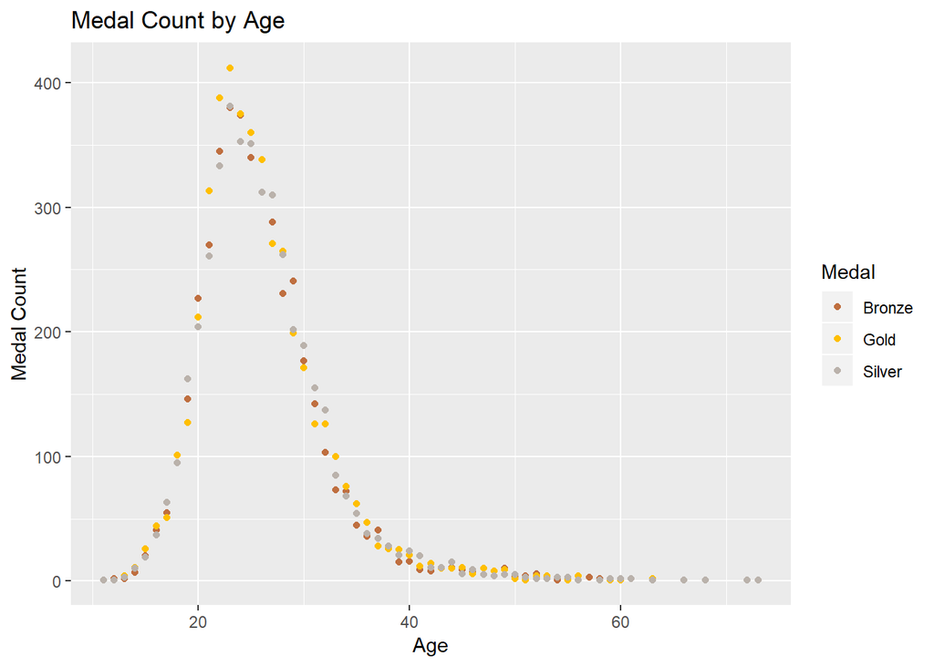

```r
  # Age vs Number of Medals: We filtered out only the athletes that receieved a medal, grouped them by age and medal, and then calculated the number of medals   received for each age. The graphs have a similar distribution to the age histogram, which is likely the effect from having more participants in the similar    # shape.
medals = olympics %>% filter(Medal == c("Gold", "Silver", "Bronze"))
medals_age = medals %>% group_by(Age, Medal) %>% count() %>% mutate(Num_Medals = n) %>% select(-n)
medals_age %>% ggplot(aes(x = Age, y = Num_Medals, colour = Medal)) + geom_point() + scale_color_manual(values=c("#bf6f40", "#ffbf00", "#bab2ab")) + ylab("Medal Count") + ggtitle("Medal Count by Age")
```

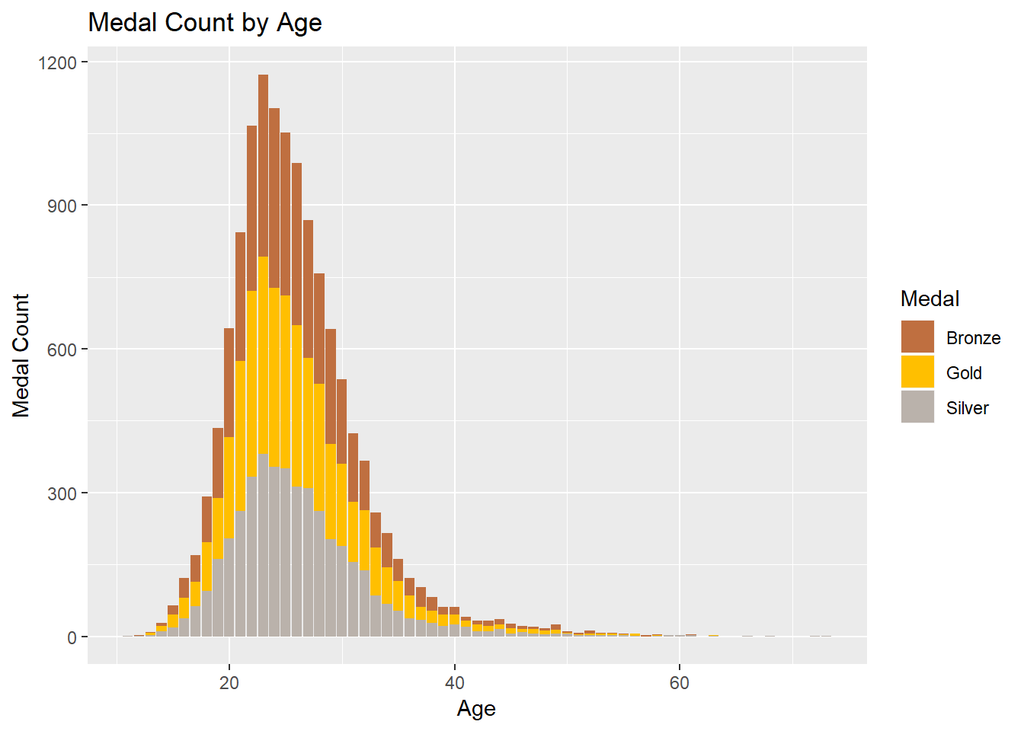

```r
medals_age %>% ggplot(aes(x = Age, y = Num_Medals, fill = Medal)) + geom_bar(stat = "identity") + scale_fill_manual(values=c("#bf6f40", "#ffbf00", "#bab2ab")) + ylab("Medal Count") + ggtitle("Medal Count by Age")
```

```r
    # Number of medals per country:
medals_country = medals %>% group_by(region, Medal) %>% count() %>% mutate(Num_Medals = n) %>% select(-n) %>% arrange(desc(Num_Medals), Medal)
```

[figure not shown]

# A closer look at the top 5

## USA: Athletes

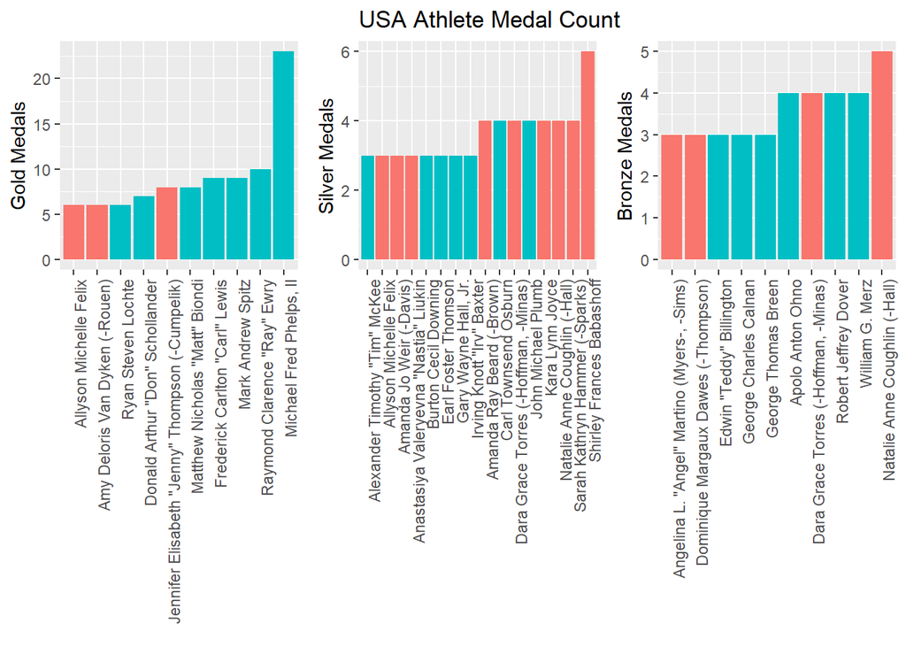

## USA: Mens Events

- Michael Fred Phelps II with 28 Medals Total
  - Swimming 4 x 200 metres Freestyle Relay: 4 Gold Medals
  - Swimming 4 x 100 metres Freestyle Relay: 1 Gold Medal
  - Swimming 4 x 100 metres Medley Relay: 4 Gold Medal

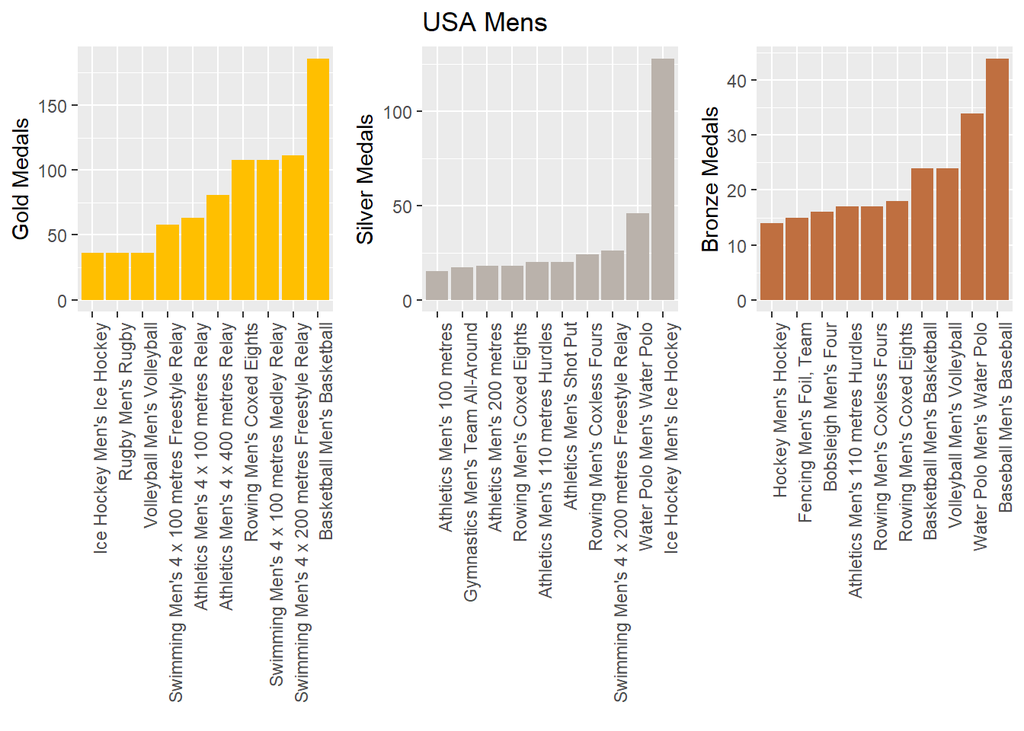

## USA: Womens Events

- Jennifer Elisabeth “Jenny” Thompson with 12 Medals Total
  - Swimming 4 x 100 metres Freestyle Relay: 3 Gold
  - Swimming 4 x 100 metres Medley Relay: 3 Gold
  - Swimming Women’s 4 x 200 metres Freestyle Relay: 2 Gold

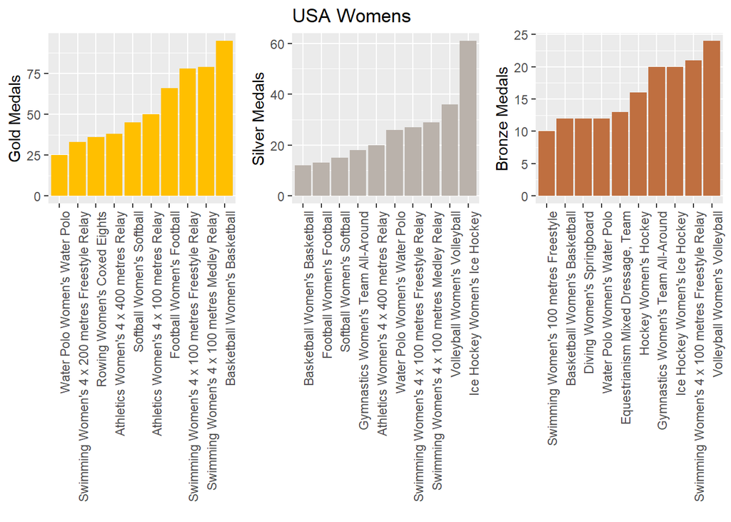

## Russia: Athletes

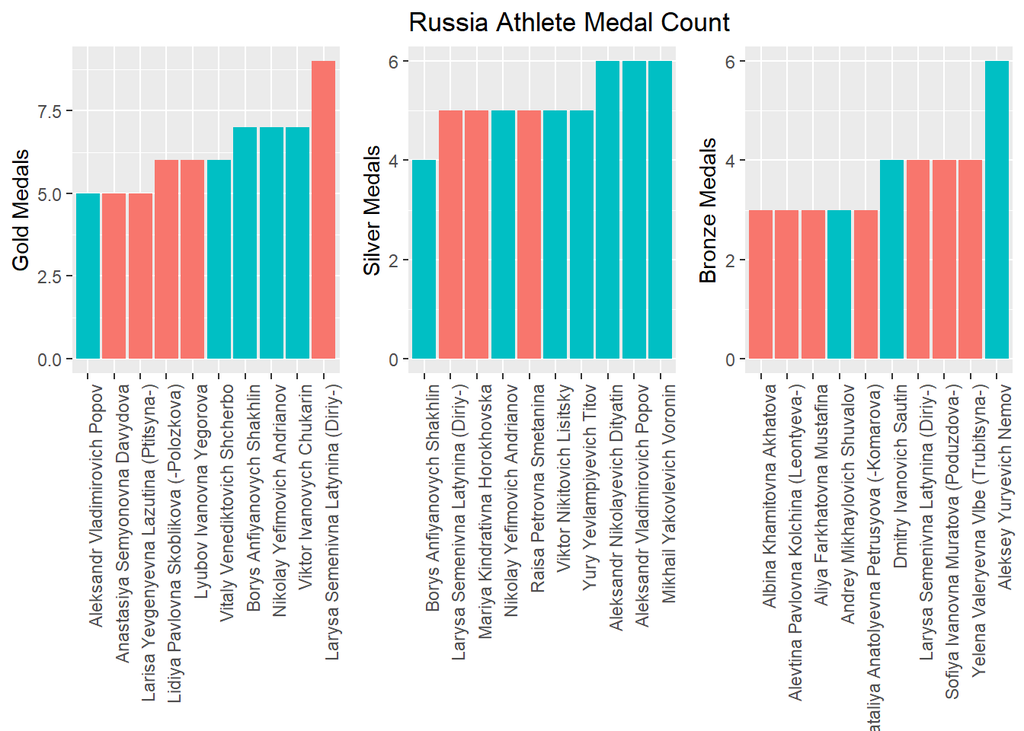

## Russia: Mens Events

- Nikolay Yefimovich Andrianov with 15 Medals Total
  - Gymnastics Team All-Around: 2 Gold

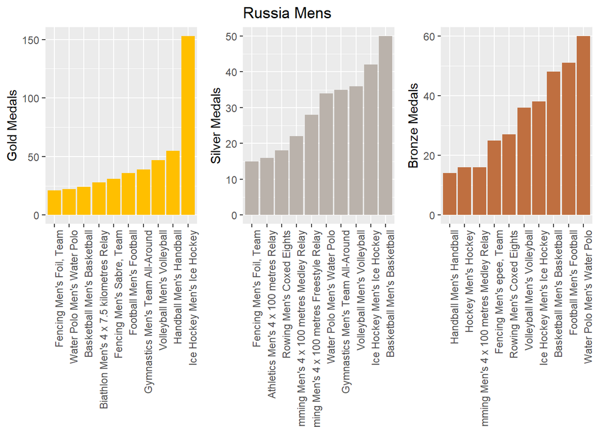

## Russia: Womens Events

- Larysa Semenivna Latynina (Diriy-) with 18 Medals Total
  - Gymnastics Team All-Around: 3 Gold

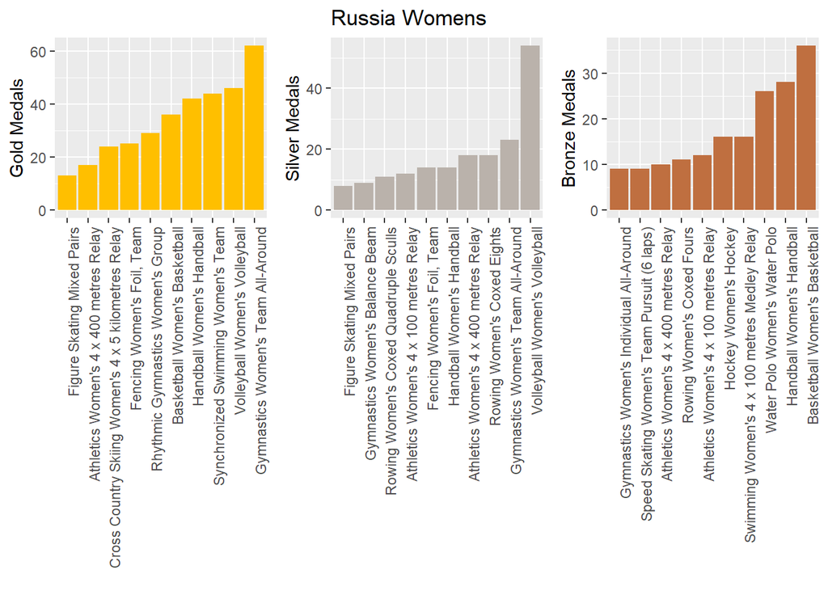

## Germany: Athletes

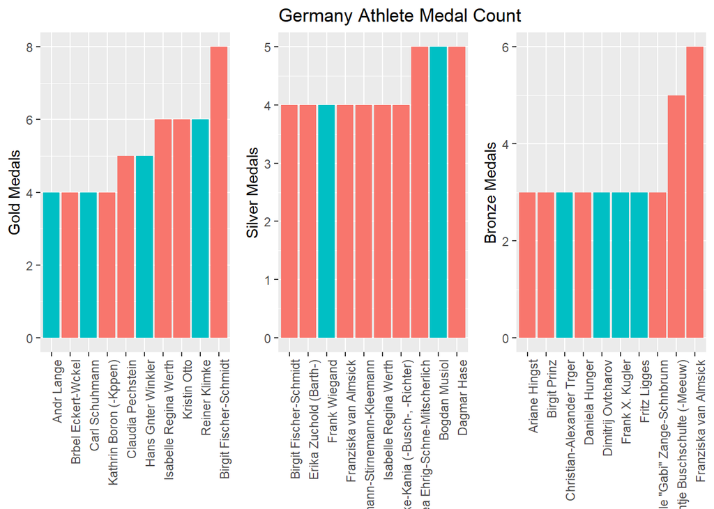

## Germany: Mens Events

- Reiner Klimke with 8 Medals Total
  - Equestrianism Mixed Jumping, Team: 5 Gold Medals

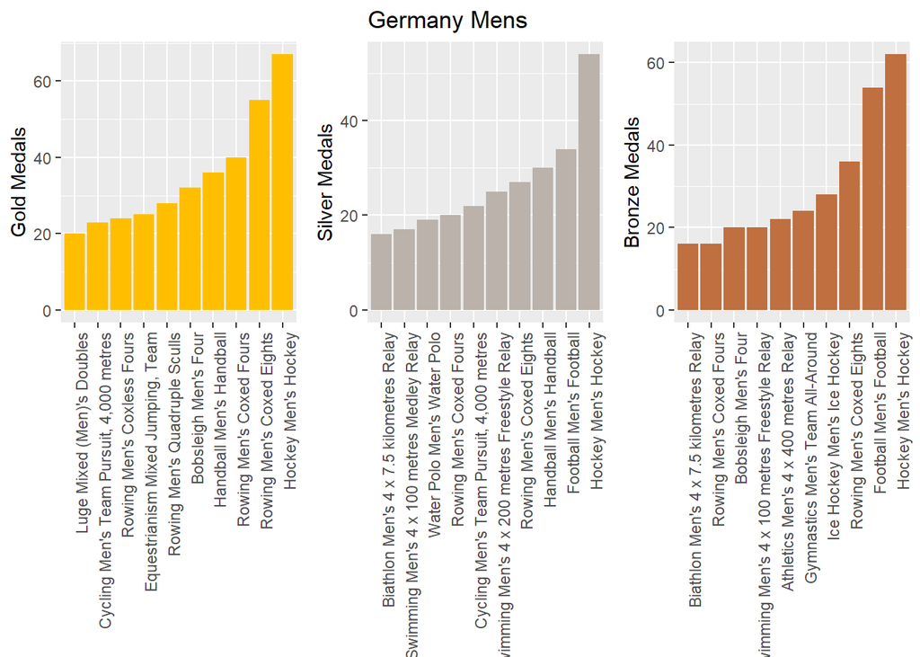

## Germany: Womens Events

- Birgit Fischer-Schmidt with 12 Medals Total
  - Canoeing Kayak Doubles, 500 metres: 2 Gold
  - Canoeing Kayak Fours, 500 metre: 3 Gold

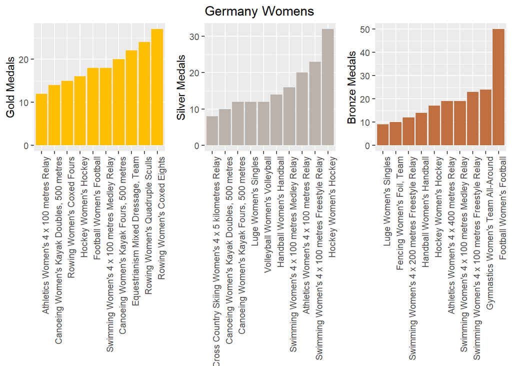

## UK: Athletes

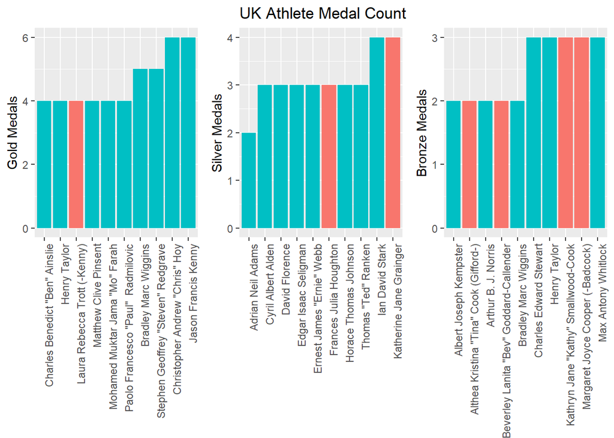

## UK: Mens Events

- Christopher Andrew “Chris” Hoy with 7 Medals Total
- Jason Francis Kenny with a total of 7 Medals
- Both Cyclists

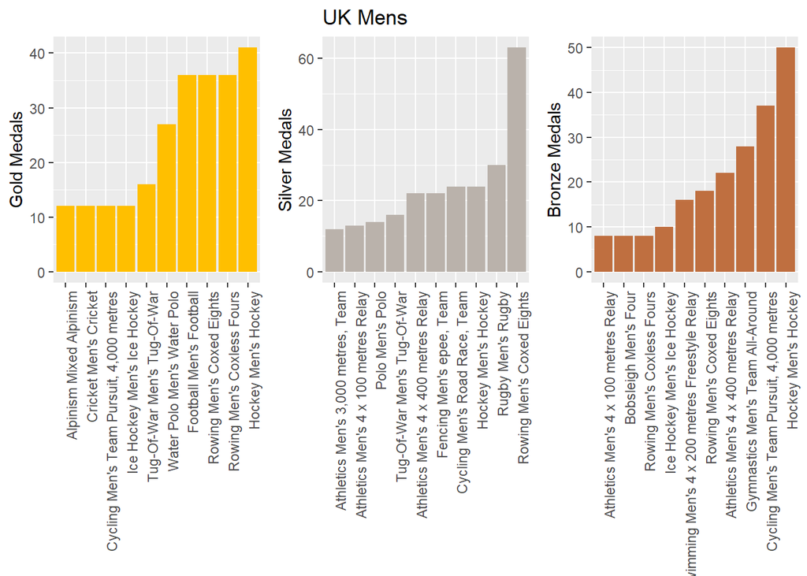

## UK: Womens Events

- Laura Rebecca Trott (-Kenny) with 4 Medals Total
  - Cycling Women’s Team Pursuit: 2 Gold

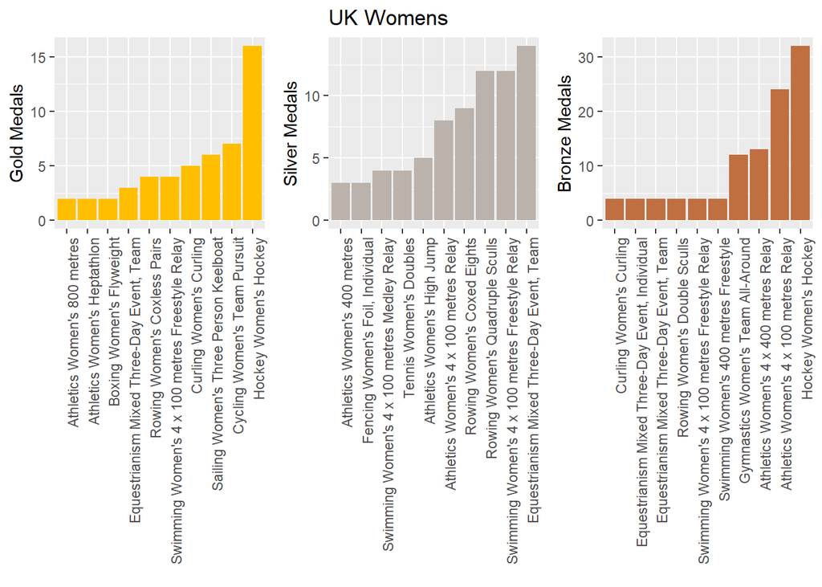

## France: Athletes

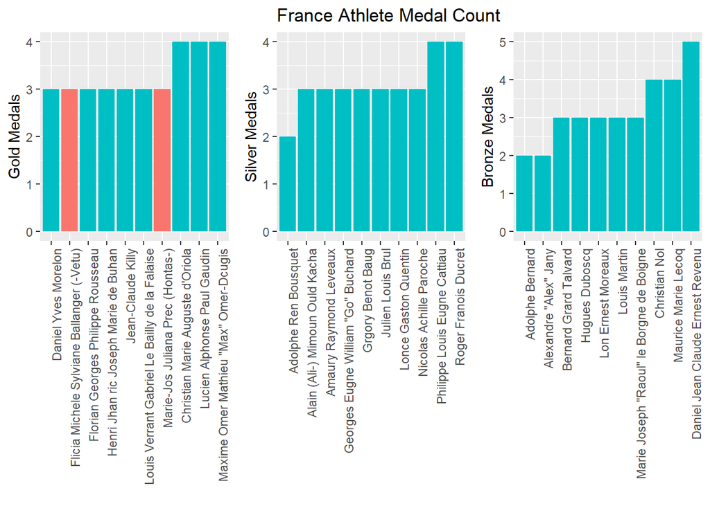

## France: Mens Events

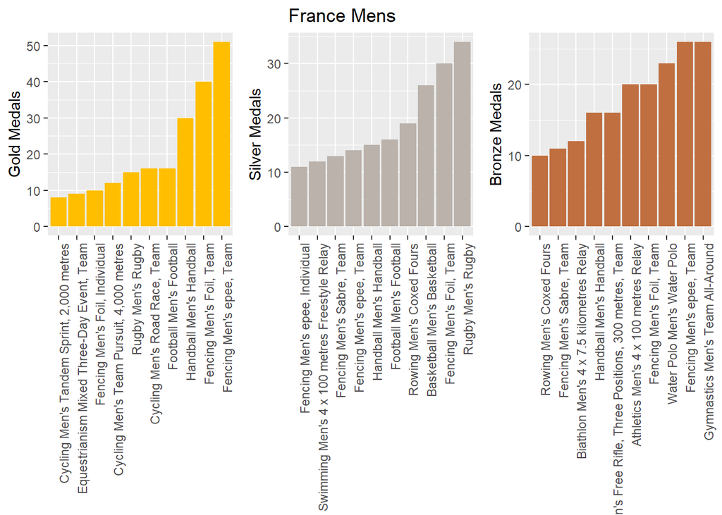